# *K-Means Clustering - Unsupervisied Machine Learning*

## *What is Clustering?*

*Clustering is dividing data points into homogeneous classes or clusters:*

- *Points in the same group are as similar as possible*
- *Points in different group are as dissimilar as possible*

*When a collection of objects is given, we put objects into group based on similarity.*

*Clustering is one of the most common exploratory data analysis technique used to get an intuition about the structure of the data. It can be defined as the task of identifying subgroups in the data such that data points in the same subgroup (cluster) are very similar while data points in different clusters are very different. In other words, we try to find homogeneous subgroups within the data such that data points in each cluster are as similar as possible according to a similarity measure such as euclidean-based distance or correlation-based distance. The decision of which similarity measure to use is application-specific.*

*Clustering analysis can be done on the basis of features where we try to find subgroups of samples based on features or on the basis of samples where we try to find subgroups of features based on samples.*

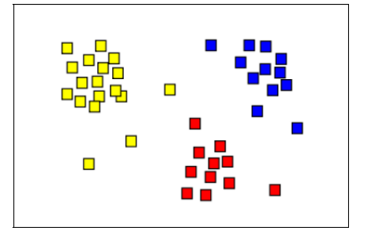

*In practice, clustering helps identify two qualities of data:*

- *Meaningfulness*
- *Usefulness*

*Meaningful* *clusters expand domain knowledge. For example, in the medical field, researchers applied clustering to gene expression experiments. The clustering results identified groups of patients who respond differently to medical treatments.*

*Useful clusters* *, on the other hand, serve as an intermediate step in a data pipeline. For example, businesses use clustering for customer segmentation. The clustering results segment customers into groups with similar purchase histories, which businesses can then use to create targeted advertising campaigns.*

*A Clustering Algorithm tries to analyse natural groups of data on the basis of some similarity. It locates the centroid of the group of data points. To carry out effective clustering, the algorithm evaluates the distance between each point from the centroid of the cluster.*

*The goal of clustering is to determine the intrinsic grouping in a set of unlabelled data.*

*Three popular categories of clustering algorithms:*

- *Partitional clustering*
- *Hierarchical clustering*
- *Density-based clustering*

### *Partitional Clustering*

*Partitional clustering divides data objects into nonoverlapping groups. In other words, no object can be a member of more than one cluster, and every cluster must have at least one object.*

*These techniques require the user to specify the number of clusters, indicated by the variable k. Many partitional clustering algorithms work through an iterative process to assign subsets of data points into k clusters. Two examples of partitional clustering algorithms are k-means and k-medoids.*

*These algorithms are both nondeterministic, meaning they could produce different results from two separate runs even if the runs were based on the same input.*

*Partitional clustering methods have several strengths:*

- *They work well when clusters have a spherical shape.*
- *They’re scalable with respect to algorithm complexity.*

*They also have several weaknesses:*

- *They’re not well suited for clusters with complex shapes and different sizes.*
- *They break down when used with clusters of different densities.*

### *Hierarchical Clustering*

*Hierarchical clustering determines cluster assignments by building a hierarchy. This is implemented by either a bottom-up or a top-down approach:*

- *Agglomerative clustering* *is the bottom-up approach. It merges the two points that are the most similar until all points have been merged into a single cluster.*
- *Divisive clustering* *is the top-down approach. It starts with all points as one cluster and splits the least similar clusters at each step until only single data points remain.*

*These methods produce a tree-based hierarchy of points called a **dendrogram**. Similar to partitional clustering, in hierarchical clustering the number of clusters (k) is often predetermined by the user. Clusters are assigned by cutting the dendrogram at a specified depth that results in k groups of smaller dendrograms.*

*Unlike many partitional clustering techniques, hierarchical clustering is a deterministic process, meaning cluster assignments won’t change when you run an algorithm twice on the same input data.*

*The strengths of hierarchical clustering methods include the following:*

- *They often reveal the finer details about the relationships between data objects.*
- *They provide an interpretable dendrogram.*

*The weaknesses of hierarchical clustering methods include the following:*

- *They’re computationally expensive with respect to algorithm complexity.*
- *They’re sensitive to noise and outliers.*

### *Density-Based Clustering*

*Density-based clustering determines cluster assignments based on the **density of data points in a region**. Clusters are assigned where there are high densities of data points separated by low-density regions.*

*Unlike the other clustering categories, this approach doesn’t require the user to specify the number of clusters. Instead, there is a distance-based parameter that acts as a tunable threshold. This threshold determines how close points must be to be considered a cluster member.*

*Examples of density-based clustering algorithms include Density-Based Spatial Clustering of Applications with Noise, or DBSCAN, and Ordering Points To Identify the Clustering Structure, or OPTICS.*

*The strengths of density-based clustering methods include the following:*

- *They excel at identifying clusters of nonspherical shapes.*
- *They’re resistant to outliers.*

*The weaknesses of density-based clustering methods include the following:*

- *They aren’t well suited for clustering in high-dimensional spaces.*
- *They have trouble identifying clusters of varying densities.*

## *Application of Clustering:*

*Listed here are few more applications, which would add to what you have learnt.*

- *Customer Segmentation*
- *Document Clustering*
- *Image Segmentation*
- *Recommendation Engines*

## *What is K-Means Clustering?*

*Kmeans algorithm is an iterative algorithm that tries to partition the dataset into Kpre-defined distinct non-overlapping subgroups (clusters) where each data point belongs to only one group. It tries to make the intra-cluster data points as similar as possible while also keeping the clusters as different (far) as possible. It assigns data points to a cluster such that the sum of the squared distance between the data points and the cluster’s centroid (arithmetic mean of all the data points that belong to that cluster) is at the minimum. The less variation we have within clusters, the more homogeneous (similar) the data points are within the same cluster.*

*In other words, the K-means algorithm identifies k number of centroids, and then allocates every data point to the nearest cluster, while keeping the centroids as small as possible.*

*The ‘means’ in the K-means refers to averaging of the data; that is, finding the centroid.*

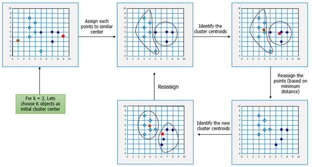

## *How K-Means works?*

*The main objective of the K-Means algorithm is to minimize the sum of distances between the points and their respective cluster centroid.*

*The way kmeans algorithm works is as follows:*

- *Specify number of clusters K.*
- *Initialize centroids by first shuffling the dataset and then randomly selecting K data points for the centroids without replacement.*
- *Keep iterating until there is no change to the centroids. i.e assignment of data points to clusters isn’t changing.*
- *Compute the sum of the squared distance between data points and all centroids.*
- *Assign each data point to the closest cluster (centroid).*
- *Compute the centroids for the clusters by taking the average of the all data points that belong to each cluster.*

*The approach kmeans follows to solve the problem is called **Expectation-Maximization**. The **E-step** is assigning the data points to the closest cluster. The **M-step** is computing the centroid of each cluster.*

*The quality of the cluster assignments is determined by computing the sum of the **squared error (SSE)** after the centroids converge, or match the previous iteration’s assignment. The SSE is defined as the **sum of the squared Euclidean distances of each point to its closest centroid**. Since this is a measure of error, the objective of k-means is to try to minimize this value.*

[figure not shown]

*The purpose of this figure is to show that the initialization of the centroids is an important step. It also highlights the use of SSE as a measure of clustering performance. After choosing a number of clusters and the initial centroids, the expectation-maximization step is repeated until the centroid positions reach convergence and are unchanged.*

*The random initialization step causes the k-means algorithm to be nondeterministic, meaning that cluster assignments will vary if you run the same algorithm twice on the same dataset. Researchers commonly run several initializations of the entire k-means algorithm and choose the cluster assignments from the initialization with the lowest SSE.*

### *Stopping Criteria for K-Means Clustering*

*There are essentially three stopping criteria that can be adopted to stop the K-means algorithm:*

- *Centroids of newly formed clusters do not change*
- *Points remain in the same cluster*
- *Maximum number of iterations are reached*

*We can stop the algorithm if the centroids of newly formed clusters are not changing. Even after multiple iterations, if we are getting the same centroids for all the clusters, we can say that the algorithm is not learning any new pattern and it is a sign to stop the training.*

*Another clear sign that we should stop the training process if the points remain in the same cluster even after training the algorithm for multiple iterations.*

*Finally, we can stop the training if the maximum number of iterations is reached. Suppose if we have set the number of iterations as 100. The process will repeat for 100 iterations before stopping.*

### *Points to remember*

- *Since clustering algorithms including kmeans use distance-based measurements to determine the similarity between data points, it’s recommended to **standardize the data** to have a mean of zero and a standard deviation of one since almost always the features in any dataset would have different units of measurements such as age vs income.*
- *Given kmeans iterative nature and the **random initialization of centroids** at the start of the algorithm, different initializations may lead to different clusters since kmeans algorithm may stuck in a local optimum and may not converge to global optimum. Therefore, it’s recommended to run the algorithm using different initializations of centroids (k-means++) and pick the results of the run that that yielded the lower sum of squared distance.*

## *Choosing the right K*

*The way to evaluate the choice of K is made using a parameter known as WCSS. **WCSS stands for Within Cluster Sum of Squares**. It should be low. Here's the formula representation for example when K = 3*

*Summation Distance(p,c) is the sum of distance of points in a cluster from the centroid.*

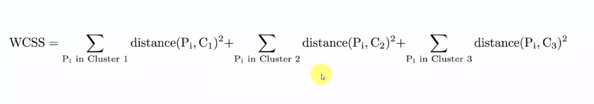

*The **Elbow Method** is then used to choose the best K value. In the depiction below we can see that after 3 there's no significant decrease in WCSS so 3 is the best here. Therefore there's an elbow shape that forms and it is usually a good idea to pick the number where this elbow is formed. There would be many times when the graph wouldn't be this intuitive but with practice it becomes easier.*

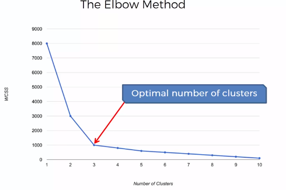

*The **silhouette coefficient** is a measure of cluster cohesion and separation. It quantifies how well a data point fits into its assigned cluster based on two factors:*

- *How close the data point is to other points in the cluster*
- *How far away the data point is from points in other clusters*

*Silhouette coefficient values range between -1 and 1. Larger numbers indicate that samples are closer to their clusters than they are to other clusters.*

*The coefficient can take values in the interval [-1, 1].*

- *If it is 0 –> the sample is very close to the neighboring clusters.*
- *It it is 1 –> the sample is far away from the neighboring clusters.*
- *It it is -1 –> the sample is assigned to the wrong clusters.*

*Therefore, we want the coefficients to be as big as possible and close to 1 to have a good clusters.*

## *Understanding K-Means with Example*

*Suppose we have a set of the following two dimensional data instances named D.*

$$D = { (5,3), (10,15), (15,12), (24,10), (30,45), (85,70), (71,80), (60,78), (55,52), (80,91) }$$

*We want to divide this data into two clusters, C1 and C2 based on the similarity between the data points.*

*The first step is to randomly initialize values for the centroids of both clusters. Let's name centroids of clusters C1 and C2 as c1 and c2 and initialize them with the values of the first two data points i.e. (5, 3) and (10, 15).*

*Now we have to start the iterations.*

*Iteration 1*

| S.No | Data Points | Euclidean Distance from Cluster Centroid c1 = (5,3) | Euclidean Distance from Cluster Centroid c2 = (10,15) | Assigned Cluster |
| --- | --- | --- | --- | --- |
| 1 | (5,3) | 0 | 13 | C1 |
| 2 | (10,15) | 13 | 0 | C2 |
| 3 | (15,12) | 13.45 | 5.83 | C2 |
| 4 | (24,10) | 20.24 | 14.86 | C2 |
| 5 | (30,45) | 48.87 | 36 | C2 |
| 6 | (85,70) | 104.35 | 93 | C2 |
| 7 | (71,80) | 101.41 | 89 | C2 |
| 8 | (60,78) | 93 | 80 | C2 |
| 9 | (55,52) | 70 | 58 | C2 |
| 10 | (80,91) | 115.52 | 103.32 | C2 |

*In the table above, the second column contains all the data points. The third column contains the Euclidean distance between all the data points and centroid c1. Similarly the fourth column contains distance between the c2 centroid and the data points. Finally, in the fifth column we show which cluster the data point is assigned to based on the Euclidean distance between the two cluster centroids. For instance, look at the third data point (15, 12). It has a distance of 13.45 units from c1 while a distance of 5.83 units from c2; therefore it has been clustered in C2.*

*After assigning data points to the corresponding clusters, the next step is to calculate the new centroid values. These values are calculated by finding the means of the coordinates of the data points that belong to a particular cluster.*

*For cluster C1, there is currently only one point i.e. (5,3), therefore the mean of the coordinates remain same and the new centroid value for c1 will also be (5,3).*

*For C2, there are currently 9 data points. We name the coordinates of data points as x and y. The new value for x coordinate of centroid c2 can be calculated by determining the mean of x coordinates of all 9 points that belong to cluster C2 as given below:*

$$c2(x) = (10 + 15 + 24 + 30 + 85 + 71 + 60 + 55 + 80) / 9 = 47.77$$

*The new value for y coordinate of centroid c2 can be calculated by determining the mean of all y coordinates of all 9 points that belong to cluster C2.*

$$c2(y) = (15 + 12 + 10 + 45 + 70 + 80 + 78 + 52 + 91) / 9 = 50.33$$

*The updated centroid value for c2 will now be {47.77, 50.33}.*

*For the next iteration, the new centroid values for c1 and c2 will be used and the whole process will be repeated. The iterations continue until the centroid values stop updating. The next iterations are as follows:*

*Iteration 2*

| S.No | Data Points | Euclidean Distance from Cluster Centroid c1 = (5,3) | Euclidean Distance from Cluster Centroid c2 = (47.77,50.33) | Assigned Cluster |
| --- | --- | --- | --- | --- |
| 1 | (5,3) | 0 | 63.79 | C1 |
| 2 | (10,15) | 13 | 51.71 | C1 |
| 3 | (15,12) | 13.45 | 50.42 | C1 |
| 4 | (24,10) | 20.24 | 46.81 | C1 |
| 5 | (30,45) | 48.87 | 18.55 | C2 |
| 6 | (85,70) | 104.35 | 42.10 | C2 |
| 7 | (71,80) | 101.41 | 37.68 | C2 |
| 8 | (60,78) | 93 | 30.25 | C2 |
| 9 | (55,52) | 70 | 7.42 | C2 |
| 10 | (80,91) | 115.52 | 51.89 | C2 |

$$c1(x) = (5, 10, 15, 24) / 4 = 13.5$$$$c1(y) = (3, 15, 12, 10) / 4 = 10.0$$

*Updated c1 to be (13.5, 10.0).*

$$c2(x) = (30 + 85 + 71 + 60 + 55 + 80) / 6 = 63.5$$$$c2(y) = (45 + 70 + 80 + 78 + 52 +91) / 6 = 69.33$$

*Updated c2 to be (63.5, 69.33).*

*Iteration 3*

| S.No | Data Points | Euclidean Distance from Cluster Centroid c1= (13.5,10) | Euclidean Distance from Cluster Centroid c2= (63.5,69.33) | Assigned Cluster |
| --- | --- | --- | --- | --- |
| 1 | (5,3) | 11.01 | 88.44 | C1 |
| 2 | (10,15) | 6.10 | 76.24 | C1 |
| 3 | (15,12) | 2.5 | 75.09 | C1 |
| 4 | (24,10) | 10.5 | 71.27 | C1 |
| 5 | (30,45) | 38.69 | 41.40 | C1 |
| 6 | (85,70) | 93.33 | 21.51 | C2 |
| 7 | (71,80) | 90.58 | 13.04 | C2 |
| 8 | (60,78) | 82.37 | 9.34 | C2 |
| 9 | (55,52) | 59.04 | 19.30 | C2 |
| 10 | (80,91) | 104.80 | 27.23 | C2 |

$$c1(x) = (5, 10, 15, 24, 30) / 5 = 16.8$$$$c1(y) = (3, 15, 12, 10, 45) / 5 = 17.0$$

*Updated c1 to be (16.8, 17.0).*

$$c2(x) = (85 + 71 + 60 + 55 + 80) / 5 = 70.2$$$$c2(y) = (70 + 80 + 78 + 52 + 91) / 5 = 74.2$$

*Updated c2 to be (70.2, 74.2).*

*Iteration 4*

| S.No | Data Points | Euclidean Distance from Cluster Centroid c1 = (16.8,17) | Euclidean Distance from Cluster Centroid c2 = (70.2,74.2) | Assigned Cluster |
| --- | --- | --- | --- | --- |
| 1 | (5,3) | 18.30 | 96.54 | C1 |
| 2 | (10,15) | 7.08 | 84.43 | C1 |
| 3 | (15,12) | 5.31 | 83.16 | C1 |
| 4 | (24,10) | 10.04 | 79.09 | C1 |
| 5 | (30,45) | 30.95 | 49.68 | C1 |
| 6 | (85,70) | 86.37 | 15.38 | C2 |
| 7 | (71,80) | 83.10 | 5.85 | C2 |
| 8 | (60,78) | 74.74 | 10.88 | C2 |
| 9 | (55,52) | 51.80 | 26.90 | C2 |
| 10 | (80,91) | 97.31 | 19.44 | C2 |

$$c1(x) = (5, 10, 15, 24, 30) / 5 = 16.8$$$$c1(y) = (3, 15, 12, 10, 45) / 5 = 17.0$$

*Updated c1 to be (16.8, 17.0).*

$$c2(x) = (85 + 71 + 60 + 55 + 80) / 5 = 70.2$$$$c2(y) = (70 + 80 + 78 + 52 + 91) / 5 = 74.2$$

*Updated c2 to be (70.2, 74.2).*

*At the end of fourth iteration, the updated values of C1 and C2 are same as they were at the end of the third iteration. This means that data cannot be clustered any further. c1 and c2 are the centroids for C1 and C2. To classify a new data point, the distance between the data point and the centroids of the clusters is calculated. Data point is assigned to the cluster whose centroid is closest to the data point.*

## *Evaluate Clusters*

### *Inertia*

*Inertia tells us how far the points within a cluster are. So, inertia actually calculates the sum of distances of all the points within a cluster from the centroid of that cluster.*

*We calculate this for all the clusters and the final inertial value is the sum of all these distances. This distance within the clusters is known as intracluster distance. So, inertia gives us the sum of intracluster distances:*

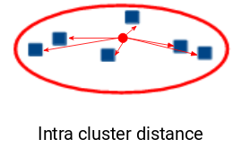

*Keeping this in mind, we can say that the lesser the inertia value, the better our clusters are.*

### *Dunn Index*

*We now know that inertia tries to minimize the intracluster distance. It is trying to make more compact clusters.*

*Let me put it this way – if the distance between the centroid of a cluster and the points in that cluster is small, it means that the points are closer to each other. So, inertia makes sure that the first property of clusters is satisfied. But it does not care about the second property – that different clusters should be as different from each other as possible.*

*This is where Dunn index can come into action.*

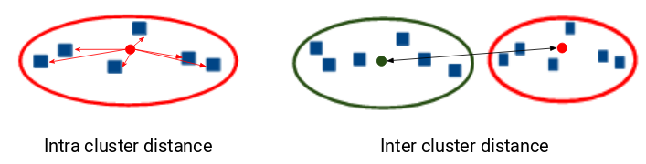

*Along with the distance between the centroid and points, the Dunn index also takes into account the distance between two clusters. This distance between the centroids of two different clusters is known as inter-cluster distance. Let’s look at the formula of the Dunn index:*

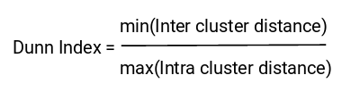

*We want to maximize the Dunn index. The more the value of the Dunn index, the better will be the clusters.*

*In order to maximize the value of the Dunn index, the numerator should be maximum. Here, we are taking the minimum of the inter-cluster distances. So, the distance between even the closest clusters should be more which will eventually make sure that the clusters are far away from each other.*

*Also, the denominator should be minimum to maximize the Dunn index. Here, we are taking the maximum of intracluster distances. Again, the intuition is the same here. The maximum distance between the cluster centroids and the points should be minimum which will eventually make sure that the clusters are compact.*

*[Reference](https://realpython.com/k-means-clustering-python/)*

```python
import pandas as pd
import numpy as np
import matplotlib.pyplot as plt

from sklearn.preprocessing import StandardScaler, normalize
from sklearn.decomposition import PCA
```

```python
from sklearn.cluster import KMeans
from sklearn.metrics import silhouette_score
```

## *Credit Card - Clustering*

```python
df = pd.read_csv(r'C:\Users\PiyushSin\Desktop\datasets\CreditCard_Clustering.csv')

df = df.drop('CUST_ID', axis = 1)
df.fillna(method ='ffill', inplace = True)

df.head(2)
```

|  | BALANCE | BALANCE_FREQUENCY | PURCHASES | ONEOFF_PURCHASES | INSTALLMENTS_PURCHASES | CASH_ADVANCE | PURCHASES_FREQUENCY | ONEOFF_PURCHASES_FREQUENCY | PURCHASES_INSTALLMENTS_FREQUENCY | CASH_ADVANCE_FREQUENCY | CASH_ADVANCE_TRX | PURCHASES_TRX | CREDIT_LIMIT | PAYMENTS | MINIMUM_PAYMENTS | PRC_FULL_PAYMENT | TENURE |
| --- | --- | --- | --- | --- | --- | --- | --- | --- | --- | --- | --- | --- | --- | --- | --- | --- | --- |
| 0 | 40.900749 | 0.818182 | 95.4 | 0.0 | 95.4 | 0.000000 | 0.166667 | 0.0 | 0.083333 | 0.00 | 0 | 2 | 1000.0 | 201.802084 | 139.509787 | 0.000000 | 12 |
| 1 | 3202.467416 | 0.909091 | 0.0 | 0.0 | 0.0 | 6442.945483 | 0.000000 | 0.0 | 0.000000 | 0.25 | 4 | 0 | 7000.0 | 4103.032597 | 1072.340217 | 0.222222 | 12 |

*[Read Before next step](https://kawahara.ca/how-to-normalize-vectors-to-unit-norm-in-python/#:~:text=If%20you%20use%20l2%2Dnormalization,1%20or%20a%20unit%20vector%20).)*

```python
# Standardize data - as we are working with distance calculations
scaler = StandardScaler()
scaled_df = scaler.fit_transform(df)

# Normalizing the Data
normalized_df = normalize(scaled_df)

# Converting the numpy array into a pandas DataFrame
normalized_df = pd.DataFrame(normalized_df)

# Reducing the dimensions of the data
pca = PCA(n_components = 2)
X_principal = pca.fit_transform(normalized_df)
X_principal = pd.DataFrame(X_principal)
X_principal.columns = ['P1', 'P2']

X_principal.head(2)
```

|  | P1 | P2 |
| --- | --- | --- |
| 0 | -0.489949 | -0.679976 |
| 1 | -0.519099 | 0.544827 |

*Elbow Criterion:*

```python
sse = {}

for k in range(1, 10):
    kmeans = KMeans(n_clusters=k,init='k-means++', max_iter=1000)
    kmeans.fit(X_principal)
    sse[k] = kmeans.inertia_ # Inertia: Sum of distances of samples to their closest cluster center
```

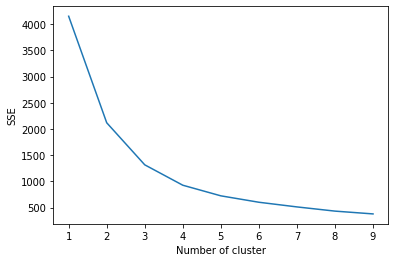

```python
plt.figure()
plt.plot(list(sse.keys()), list(sse.values()))
plt.xlabel("Number of cluster")
plt.ylabel("SSE")
plt.show()
```

*Silhouette Coefficient Method:*

```python
silhouette_scores = []

for n_cluster in range(2, 8):
    kmeans = KMeans(n_clusters = n_cluster)
    kmeans.fit(X_principal)
    score = silhouette_score(X_principal,kmeans.predict(X_principal))
    silhouette_scores.append(score)
```

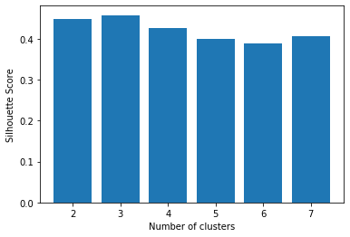

```python
# Plotting a bar graph to compare the results
k = [2, 3, 4, 5, 6, 7]
plt.bar(k, silhouette_scores)
plt.xlabel('Number of clusters', fontsize = 10)
plt.ylabel('Silhouette Score', fontsize = 10)
plt.show()
```

*Upon analyzing the output from the above 2 methods, no. of clusters = 3 seems to fir well.*

```python
kmeans = KMeans(n_clusters=3,init='k-means++', max_iter=1000)
kmeans.fit(X_principal)
```

```
KMeans(max_iter=1000, n_clusters=3)
```

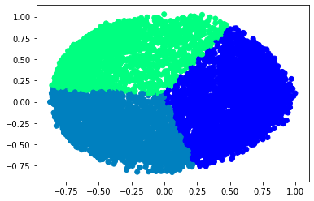

```python
# Visualizing the clustering
plt.scatter(X_principal['P1'], X_principal['P2'],
           c = KMeans(n_clusters = 3).fit_predict(X_principal), cmap =plt.cm.winter)
plt.show()
```

## *K-Modes Clustering*

```python
bank = pd.read_csv(r'C:\Users\PiyushSin\Desktop\datasets\bankmarketing.csv')
bank.head()
```

|  | age | job | marital | education | default | housing | loan | contact | month | day_of_week | ... | campaign | pdays | previous | poutcome | emp.var.rate | cons.price.idx | cons.conf.idx | euribor3m | nr.employed | y |
| --- | --- | --- | --- | --- | --- | --- | --- | --- | --- | --- | --- | --- | --- | --- | --- | --- | --- | --- | --- | --- | --- |
| 0 | 56 | housemaid | married | basic.4y | no | no | no | telephone | may | mon | ... | 1 | 999 | 0 | nonexistent | 1.1 | 93.994 | -36.4 | 4.857 | 5191.0 | no |
| 1 | 57 | services | married | high.school | unknown | no | no | telephone | may | mon | ... | 1 | 999 | 0 | nonexistent | 1.1 | 93.994 | -36.4 | 4.857 | 5191.0 | no |
| 2 | 37 | services | married | high.school | no | yes | no | telephone | may | mon | ... | 1 | 999 | 0 | nonexistent | 1.1 | 93.994 | -36.4 | 4.857 | 5191.0 | no |
| 3 | 40 | admin. | married | basic.6y | no | no | no | telephone | may | mon | ... | 1 | 999 | 0 | nonexistent | 1.1 | 93.994 | -36.4 | 4.857 | 5191.0 | no |
| 4 | 56 | services | married | high.school | no | no | yes | telephone | may | mon | ... | 1 | 999 | 0 | nonexistent | 1.1 | 93.994 | -36.4 | 4.857 | 5191.0 | no |

5 rows × 21 columns

```python
bank.columns
```

```
Index(['age', 'job', 'marital', 'education', 'default', 'housing', 'loan',
       'contact', 'month', 'day_of_week', 'duration', 'campaign', 'pdays',
       'previous', 'poutcome', 'emp.var.rate', 'cons.price.idx',
       'cons.conf.idx', 'euribor3m', 'nr.employed', 'y'],
      dtype='object')
```

```python
bank_cust = bank[['age','job', 'marital', 'education', 'default', 'housing', 'loan','contact','month','day_of_week','poutcome']]
```

```python
bank_cust.head()
```

|  | age | job | marital | education | default | housing | loan | contact | month | day_of_week | poutcome |
| --- | --- | --- | --- | --- | --- | --- | --- | --- | --- | --- | --- |
| 0 | 56 | housemaid | married | basic.4y | no | no | no | telephone | may | mon | nonexistent |
| 1 | 57 | services | married | high.school | unknown | no | no | telephone | may | mon | nonexistent |
| 2 | 37 | services | married | high.school | no | yes | no | telephone | may | mon | nonexistent |
| 3 | 40 | admin. | married | basic.6y | no | no | no | telephone | may | mon | nonexistent |
| 4 | 56 | services | married | high.school | no | no | yes | telephone | may | mon | nonexistent |

```python
bank_cust['age_bin'] = pd.cut(bank_cust['age'], [0, 20, 30, 40, 50, 60, 70, 80, 90, 100],
                              labels=['0-20', '20-30', '30-40', '40-50','50-60','60-70','70-80', '80-90','90-100'])

bank_cust  = bank_cust.drop('age',axis = 1)
```

```python
bank_cust.head()
```

|  | job | marital | education | default | housing | loan | contact | month | day_of_week | poutcome | age_bin |
| --- | --- | --- | --- | --- | --- | --- | --- | --- | --- | --- | --- |
| 0 | housemaid | married | basic.4y | no | no | no | telephone | may | mon | nonexistent | 50-60 |
| 1 | services | married | high.school | unknown | no | no | telephone | may | mon | nonexistent | 50-60 |
| 2 | services | married | high.school | no | yes | no | telephone | may | mon | nonexistent | 30-40 |
| 3 | admin. | married | basic.6y | no | no | no | telephone | may | mon | nonexistent | 30-40 |
| 4 | services | married | high.school | no | no | yes | telephone | may | mon | nonexistent | 50-60 |

```python
bank_cust.describe()
```

|  | job | marital | education | default | housing | loan | contact | month | day_of_week | poutcome | age_bin |
| --- | --- | --- | --- | --- | --- | --- | --- | --- | --- | --- | --- |
| count | 41188 | 41188 | 41188 | 41188 | 41188 | 41188 | 41188 | 41188 | 41188 | 41188 | 41188 |
| unique | 12 | 4 | 8 | 3 | 3 | 3 | 2 | 10 | 5 | 3 | 9 |
| top | admin. | married | university.degree | no | yes | no | cellular | may | thu | nonexistent | 30-40 |
| freq | 10422 | 24928 | 12168 | 32588 | 21576 | 33950 | 26144 | 13769 | 8623 | 35563 | 16385 |

```python
bank_cust.info()
```

```
<class 'pandas.core.frame.DataFrame'>
RangeIndex: 41188 entries, 0 to 41187
Data columns (total 11 columns):
job            41188 non-null object
marital        41188 non-null object
education      41188 non-null object
default        41188 non-null object
housing        41188 non-null object
loan           41188 non-null object
contact        41188 non-null object
month          41188 non-null object
day_of_week    41188 non-null object
poutcome       41188 non-null object
age_bin        41188 non-null category
dtypes: category(1), object(10)
memory usage: 3.2+ MB
```

```python
# Checking Null values
bank_cust.isnull().sum()*100/bank_cust.shape[0]
# There are no NULL values in the dataset, hence it is clean.
```

```
job            0.0
marital        0.0
education      0.0
default        0.0
housing        0.0
loan           0.0
contact        0.0
month          0.0
day_of_week    0.0
poutcome       0.0
age_bin        0.0
dtype: float64
```

```python
# First we will keep a copy of data
bank_cust_copy = bank_cust.copy()
```

```python
from sklearn import preprocessing
le = preprocessing.LabelEncoder()
bank_cust = bank_cust.apply(le.fit_transform)
bank_cust.head()
```

|  | job | marital | education | default | housing | loan | contact | month | day_of_week | poutcome | age_bin |
| --- | --- | --- | --- | --- | --- | --- | --- | --- | --- | --- | --- |
| 0 | 3 | 1 | 0 | 0 | 0 | 0 | 1 | 6 | 1 | 1 | 4 |
| 1 | 7 | 1 | 3 | 1 | 0 | 0 | 1 | 6 | 1 | 1 | 4 |
| 2 | 7 | 1 | 3 | 0 | 2 | 0 | 1 | 6 | 1 | 1 | 2 |
| 3 | 0 | 1 | 1 | 0 | 0 | 0 | 1 | 6 | 1 | 1 | 2 |
| 4 | 7 | 1 | 3 | 0 | 0 | 2 | 1 | 6 | 1 | 1 | 4 |

```python
# Importing Libraries

from kmodes.kmodes import KModes
```

```python
# Using K-Mode with "Cao" initialization
km_cao = KModes(n_clusters=2, init = "Cao", n_init = 1, verbose=1)
fitClusters_cao = km_cao.fit_predict(bank_cust)
```

```
Init: initializing centroids
Init: initializing clusters
Starting iterations...
Run 1, iteration: 1/100, moves: 5322, cost: 192203.0
Run 1, iteration: 2/100, moves: 1160, cost: 192203.0
```

```python
# Predicted Clusters
fitClusters_cao
```

```
array([1, 1, 0, ..., 0, 1, 0], dtype=uint16)
```

```python
clusterCentroidsDf = pd.DataFrame(km_cao.cluster_centroids_)
clusterCentroidsDf.columns = bank_cust.columns
```

```python
# Mode of the clusters
clusterCentroidsDf
```

|  | job | marital | education | default | housing | loan | contact | month | day_of_week | poutcome | age_bin |
| --- | --- | --- | --- | --- | --- | --- | --- | --- | --- | --- | --- |
| 0 | 0 | 1 | 6 | 0 | 2 | 0 | 0 | 6 | 2 | 1 | 2 |
| 1 | 1 | 1 | 3 | 0 | 0 | 0 | 1 | 6 | 0 | 1 | 3 |

```python
# Using K-Mode with "Huang" initialization
km_huang = KModes(n_clusters=2, init = "Huang", n_init = 1, verbose=1)
fitClusters_huang = km_huang.fit_predict(bank_cust)
```

```
Init: initializing centroids
Init: initializing clusters
Starting iterations...
Run 1, iteration: 1/100, moves: 5833, cost: 198516.0
Run 1, iteration: 2/100, moves: 0, cost: 198516.0
```

```python
# Predicted clusters
fitClusters_huang
```

```
array([0, 0, 0, ..., 0, 1, 0], dtype=uint16)
```

```python
# Choosing K by comparing Cost against each K
cost = []
for num_clusters in list(range(1,5)):
    kmode = KModes(n_clusters=num_clusters, init = "Cao", n_init = 1, verbose=1)
    kmode.fit_predict(bank_cust)
    cost.append(kmode.cost_)
```

```
Init: initializing centroids
Init: initializing clusters
Starting iterations...
Run 1, iteration: 1/100, moves: 0, cost: 216952.0
Init: initializing centroids
Init: initializing clusters
Starting iterations...
Run 1, iteration: 1/100, moves: 5322, cost: 192203.0
Run 1, iteration: 2/100, moves: 1160, cost: 192203.0
Init: initializing centroids
Init: initializing clusters
Starting iterations...
Run 1, iteration: 1/100, moves: 4993, cost: 185138.0
Run 1, iteration: 2/100, moves: 1368, cost: 185138.0
Init: initializing centroids
Init: initializing clusters
Starting iterations...
Run 1, iteration: 1/100, moves: 6186, cost: 179774.0
Run 1, iteration: 2/100, moves: 1395, cost: 179774.0
```

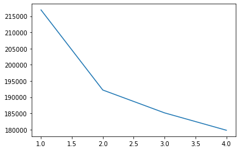

```python
y = np.array([i for i in range(1,5,1)])
plt.plot(y,cost)
```

```python
## Choosing K=2
km_cao = KModes(n_clusters=2, init = "Cao", n_init = 1, verbose=1)
fitClusters_cao = km_cao.fit_predict(bank_cust)
```

```
Init: initializing centroids
Init: initializing clusters
Starting iterations...
Run 1, iteration: 1/100, moves: 5322, cost: 192203.0
Run 1, iteration: 2/100, moves: 1160, cost: 192203.0
```

```python
fitClusters_cao
```

```
array([1, 1, 0, ..., 0, 1, 0], dtype=uint16)
```

```python
# Combining the predicted clusters with the original DF.
bank_cust = bank_cust_copy.reset_index()
clustersDf = pd.DataFrame(fitClusters_cao)
clustersDf.columns = ['cluster_predicted']
combinedDf = pd.concat([bank_cust, clustersDf], axis = 1).reset_index()
combinedDf = combinedDf.drop(['index', 'level_0'], axis = 1)
```

```python
combinedDf.head()
```

|  | job | marital | education | default | housing | loan | contact | month | day_of_week | poutcome | age_bin | cluster_predicted |
| --- | --- | --- | --- | --- | --- | --- | --- | --- | --- | --- | --- | --- |
| 0 | housemaid | married | basic.4y | no | no | no | telephone | may | mon | nonexistent | 50-60 | 1 |
| 1 | services | married | high.school | unknown | no | no | telephone | may | mon | nonexistent | 50-60 | 1 |
| 2 | services | married | high.school | no | yes | no | telephone | may | mon | nonexistent | 30-40 | 0 |
| 3 | admin. | married | basic.6y | no | no | no | telephone | may | mon | nonexistent | 30-40 | 0 |
| 4 | services | married | high.school | no | no | yes | telephone | may | mon | nonexistent | 50-60 | 1 |

```python
# Cluster Identification
cluster_0 = combinedDf[combinedDf['cluster_predicted'] == 0]
cluster_1 = combinedDf[combinedDf['cluster_predicted'] == 1]
cluster_0.info()
```

```
<class 'pandas.core.frame.DataFrame'>
Int64Index: 28293 entries, 2 to 41187
Data columns (total 12 columns):
job                  28293 non-null object
marital              28293 non-null object
education            28293 non-null object
default              28293 non-null object
housing              28293 non-null object
loan                 28293 non-null object
contact              28293 non-null object
month                28293 non-null object
day_of_week          28293 non-null object
poutcome             28293 non-null object
age_bin              28293 non-null category
cluster_predicted    28293 non-null uint16
dtypes: category(1), object(10), uint16(1)
memory usage: 2.5+ MB
```

```python
cluster_1.info()
```

```
<class 'pandas.core.frame.DataFrame'>
Int64Index: 12895 entries, 0 to 41186
Data columns (total 12 columns):
job                  12895 non-null object
marital              12895 non-null object
education            12895 non-null object
default              12895 non-null object
housing              12895 non-null object
loan                 12895 non-null object
contact              12895 non-null object
month                12895 non-null object
day_of_week          12895 non-null object
poutcome             12895 non-null object
age_bin              12895 non-null category
cluster_predicted    12895 non-null uint16
dtypes: category(1), object(10), uint16(1)
memory usage: 1.1+ MB
```

*[Reference](https://www.youtube.com/watch?v=x7pdjCxzo1A)* *[Reference](https://www.quora.com/How-do-we-apply-k-means-clustering-algorithm-for-mixed-data-numeric-and-categorical/answer/Shehroz-Khan-2)*